# Statistical Analysis of GPP

Jaideep Joshi

13-8-2025

## Introduction

In this tutorial, we explore the R programming language and tidy data analysis techniques. We will do so through building a statistical model of Gross Primary Productivity (GPP), i.e., the total amount of carbon captured by plants through photosynthesis. The tutorial is structured to guide you step-by-step, starting from loading raw data, tansforming data into various tidy formats, fitting a statistical model for GPP, and performing complex visualizations using the tidyverse ecosystem in R.

By the end of this tutorial, you will have a solid understanding of how to manipulate, visualize, and model data in R.

## 0. Load Required Libraries

To begin, we load the tidyverse, a collection of R packages designed for data science. The tidyverse includes several powerful tools such as: - `ggplot2` for creating elegant data visualizations. - `dplyr` for data manipulation. - `tidyr` for reshaping and cleaning data.

```r
library(tidyverse)
```

## 1. Load Required Data

In this section, we ensure that the required data files are available locally. If not, they can be downloaded from the provided URLs. These files contain the drivers (temperature, vapour pressure deficit, etc) and validation (GPP) data for fitting our model. Note that these files are originally used for a process-based model of GPP called the P model, but in this tutorial, we will not use the P model itself, we will only use its drivers and validation data.

```r
# download.file(
#   url = "https://github.com/jaideep777/rsofun/raw/phydro_new/data/p_model_drivers.rda",
#   destfile = "data/p_model_drivers.rda",
#   mode = "wb"
# )

# download.file(
#   url = "https://github.com/jaideep777/rsofun/raw/phydro_new/data/p_model_validation.rda",
#   destfile = "data/p_model_validation.rda",
#   mode = "wb"
# )
```

Once the files are downloaded, we load them into R. These `.rda` files contain pre-processed datasets in binary format that will be used throughout the tutorial.

```r
load(here::here("data/p_model_drivers.rda"))
load(here::here("data/p_model_validation.rda"))
```

## 2. Tidy data formats (long, wide, and nested)

Before doing any analysis or plotting, it’s important to understand how data can be organized.

In practice, you will often encounter three common formats:

### ✅ Wide format

Each variable has its own column, and each row represents one observation in time or space.

Example (conceptually):

| date | temp | vpd | ppfd |
| --- | --- | --- | --- |
| t1 | … | … | … |

This format is convenient for regression models, but not ideal for plotting many variables at once.

### ✅ Long format

Variable names are stored in one column, and their values in another.

Example:

| date | name | value |
| --- | --- | --- |
| t1 | temp | … |
| t1 | vpd | … |

Long format is especially useful for:

- ggplot visualizations
- faceted plots
- grouped summaries

Most tidyverse tools expect or work best with long data.

### ✅ Nested format

Nested data is when a column itself contains a *data frame*.

Instead of holding numbers directly, a column may hold an entire table per row.

This is common when:

- data are grouped by site
- multiple time series are stored together
- models are stored inside tables

In our case, `p_model_drivers` contains a column called `forcing` that holds a small data frame for each site.

Here, we demonstrate how to unnest the `forcing` column from the drivers dataset, remove unnecessary columns, and convert the data between wide and long formats. This is a crucial step for preparing data for analysis and visualization.

```r
p_model_drivers |> colnames()
```

```
## [1] "sitename"    "params_siml" "site_info"   "forcing"
```

```r
# Nested data format
p_model_drivers
```

```
## # A tibble: 1 × 4
##   sitename params_siml       site_info        forcing
##   <chr>    <list>            <list>           <list>
## 1 FR-Pue   <tibble [1 × 11]> <tibble [1 × 4]> <tibble [2,190 × 13]>
```

```r
# Wide data format
p_model_drivers |> unnest(forcing)
```

```
## # A tibble: 2,190 × 16
##    sitename params_siml site_info date        temp   vpd      ppfd netrad   patm
##    <chr>    <list>      <list>    <date>     <dbl> <dbl>     <dbl>  <dbl>  <dbl>
##  1 FR-Pue   <tibble>    <tibble>  2007-01-01 10.0  183.  0.000106    4.17 9.99e4
##  2 FR-Pue   <tibble>    <tibble>  2007-01-02  8.42 417.  0.000192  -22.2  1.00e5
##  3 FR-Pue   <tibble>    <tibble>  2007-01-03  9.13 566.  0.000187  -16.6  1.00e5
##  4 FR-Pue   <tibble>    <tibble>  2007-01-04 10.1  375.  0.0000828 -16.8  9.93e4
##  5 FR-Pue   <tibble>    <tibble>  2007-01-05 10.7  508.  0.000183   -6.60 9.94e4
##  6 FR-Pue   <tibble>    <tibble>  2007-01-06 13.6  656.  0.000188  -11.2  9.95e4
##  7 FR-Pue   <tibble>    <tibble>  2007-01-07 13.7  567.  0.000155    7.32 9.93e4
##  8 FR-Pue   <tibble>    <tibble>  2007-01-08 10.7  273.  0.0000717  -3.00 9.89e4
##  9 FR-Pue   <tibble>    <tibble>  2007-01-09 16.4  682.  0.000188    9.94 9.91e4
## 10 FR-Pue   <tibble>    <tibble>  2007-01-10 11.4   26.0 0.0000277  -6.41 9.94e4
## # ℹ 2,180 more rows
## # ℹ 7 more variables: snow <dbl>, rain <dbl>, tmin <dbl>, tmax <dbl>,
## #   fapar <dbl>, co2 <dbl>, ccov <dbl>
```

```r
# Long data format
p_model_drivers |>
  unnest(forcing) |>
  pivot_longer(-(sitename:date))
```

```
## # A tibble: 26,280 × 6
##    sitename params_siml       site_info        date       name           value
##    <chr>    <list>            <list>           <date>     <chr>          <dbl>
##  1 FR-Pue   <tibble [1 × 11]> <tibble [1 × 4]> 2007-01-01 temp      10.0
##  2 FR-Pue   <tibble [1 × 11]> <tibble [1 × 4]> 2007-01-01 vpd      183.
##  3 FR-Pue   <tibble [1 × 11]> <tibble [1 × 4]> 2007-01-01 ppfd       0.000106
##  4 FR-Pue   <tibble [1 × 11]> <tibble [1 × 4]> 2007-01-01 netrad     4.17
##  5 FR-Pue   <tibble [1 × 11]> <tibble [1 × 4]> 2007-01-01 patm   99944.
##  6 FR-Pue   <tibble [1 × 11]> <tibble [1 × 4]> 2007-01-01 snow       0
##  7 FR-Pue   <tibble [1 × 11]> <tibble [1 × 4]> 2007-01-01 rain       0.0000255
##  8 FR-Pue   <tibble [1 × 11]> <tibble [1 × 4]> 2007-01-01 tmin       7.12
##  9 FR-Pue   <tibble [1 × 11]> <tibble [1 × 4]> 2007-01-01 tmax      13.0
## 10 FR-Pue   <tibble [1 × 11]> <tibble [1 × 4]> 2007-01-01 fapar      0.605
## # ℹ 26,270 more rows
```

You may notice the symbol `|>` in the code above. This is called the **pipe operator**.

The pipe operator takes the result of the expression on its left and automatically passes it as the *first argument* to the function on its right.

Conceptually, `p_model_drivers |> unnest(forcing)` is the same as `unnest(p_model_drivers, forcing)`. It means, “Take the drivers object, apply the unnest function to it, with forcing as it’s seconf argument”.

Using pipes makes code easier to read because it follows a left-to-right workflow, similar to natural language: Read the data, then show the first rows, then plot, etc.

This style becomes especially powerful when chaining many operations together (reading data → cleaning → reshaping → plotting).

### Milestone 2: Appropriately unnest the validation dataset

Similarly, we unnest the `data` column from the validation dataset to make it easier to work with. This step ensures that all variables are accessible for analysis.

```
## # A tibble: 2,190 × 4
##    sitename date         gpp gpp_unc
##    <chr>    <date>     <dbl>   <dbl>
##  1 FR-Pue   2007-01-01 2.21  0.0108
##  2 FR-Pue   2007-01-02 2.23  0.00475
##  3 FR-Pue   2007-01-03 2.48  0.00727
##  4 FR-Pue   2007-01-04 1.71  0.00516
##  5 FR-Pue   2007-01-05 2.61  0.00764
##  6 FR-Pue   2007-01-06 2.85  0.00610
##  7 FR-Pue   2007-01-07 2.80  0.0164
##  8 FR-Pue   2007-01-08 1.90  0.0116
##  9 FR-Pue   2007-01-09 3.42  0.0147
## 10 FR-Pue   2007-01-10 0.651 0.0151
## # ℹ 2,180 more rows
```

## 3. Visualize P Model Drivers

Visualization is a powerful tool for understanding data. In this section, we create a line plot to visualize the trend of a single driver variable (e.g., VPD) over time. This helps us identify patterns and anomalies in the data.

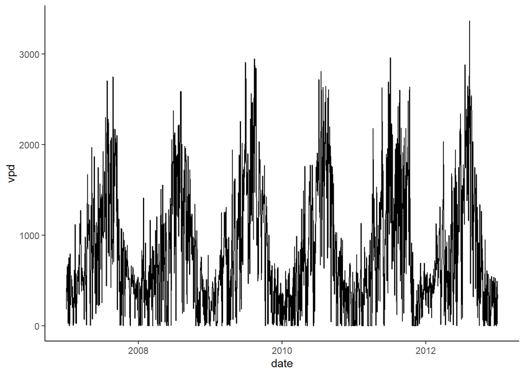

```r
p_model_drivers |>
  unnest(cols=forcing) |>
  ggplot(aes(x=date, y=vpd))+
  geom_line()+
  theme_classic()
```

### Milestone 3: Plot all drivers over time in a multi-faceted plot

To gain a comprehensive view of all driver variables, we create a multi-faceted plot. This involves selecting specific columns, reshaping the data into long format, and using `facet_wrap()` to create separate panels for each variable.

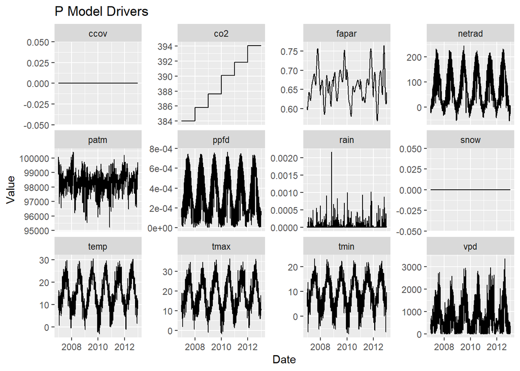

## 4. Visualize P Model Validation Data

Here, we visualize the validation dataset in a similar manner. This allows us to compare observed GPP values with the drivers and identify relationships between them.

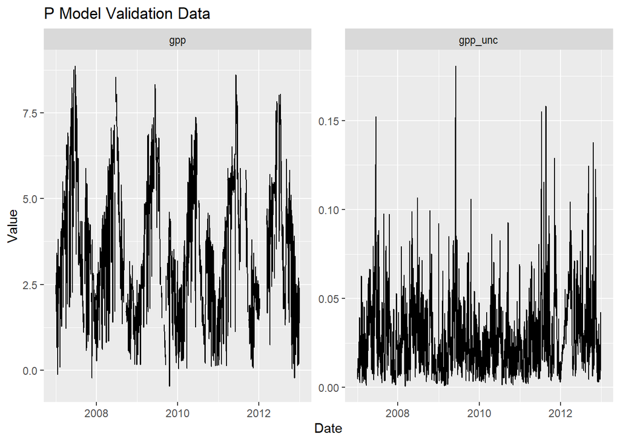

```r
p_model_validation |>
  unnest(cols=data) |>
  select(-sitename) |>
  pivot_longer(-date) |>
  ggplot(aes(x=date, y=value)) +
  geom_line() +
  facet_wrap(~name, scales = "free_y") +
  labs(x = "Date", y = "Value", title = "P Model Validation Data")
```

### Milestone 4: Plot the uncertainty values as a band around GPP

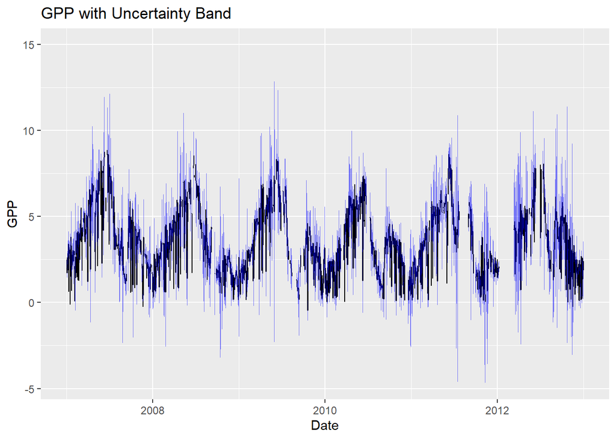

## 5. Combine Drivers and Validation Data

To analyze the relationship between drivers and validation data, we join the two datasets by date. This creates a combined dataset that includes both observed GPP and the corresponding driver variables.

```r
p_model_combined =
  p_model_drivers |>
  unnest(cols=forcing) |>
  select(-params_siml, -site_info, -sitename) |>
  left_join(
    p_model_validation |>
    unnest(cols=data) |>
    select(date, gpp)
  )
```

## 6. Visualize Combined Data

We plot all variables from the combined dataset over time to identify trends and relationships between the drivers and observed GPP.

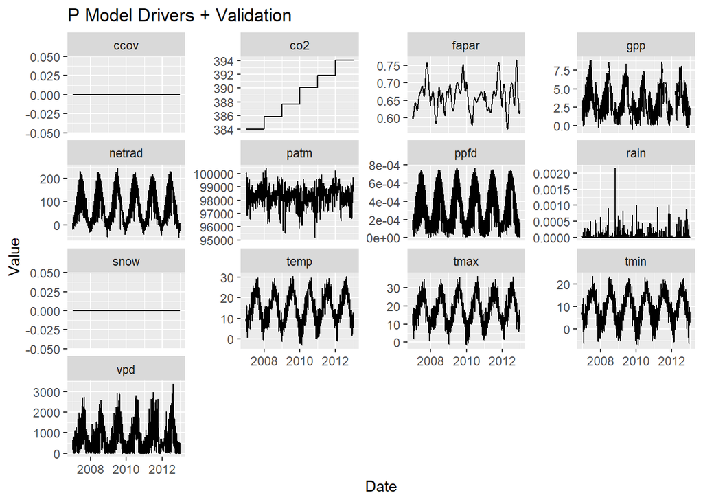

## 7. Fit a Linear Model

In this section, we fit a simple linear model to predict GPP based on light (PPFD). This demonstrates the concept of light-use efficiency and provides a baseline for more complex models.

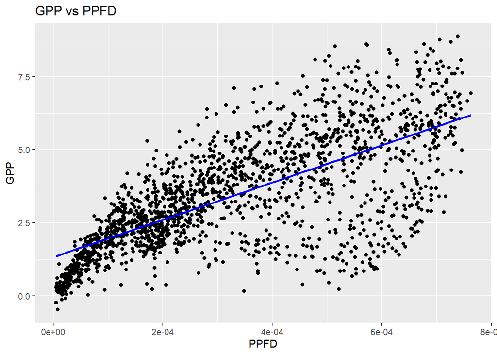

```r
p_model_combined |>
  ggplot(aes(x=ppfd, y=gpp)) +
  geom_point() +
  geom_smooth(method = "lm", se = FALSE, color = "blue") +
  labs(x = "PPFD", y = "GPP", title = "GPP vs PPFD")
```

```r
mod = p_model_combined |>
  with(lm(gpp~ppfd))

mod |> broom::tidy()
```

```
## # A tibble: 2 × 5
##   term        estimate std.error statistic   p.value
##   <chr>          <dbl>     <dbl>     <dbl>     <dbl>
## 1 (Intercept)     1.32    0.0605      21.8 4.11e- 94
## 2 ppfd         6377.    153.          41.7 1.77e-266
```

## 8. Add Predicted GPP to the Data

Using the fitted model, we predict GPP values and add them to the combined dataset. This allows us to compare observed and predicted GPP.

```r
# Add predicted gpp to the combined data
p_model_obs_vs_pred <- p_model_combined |>
  mutate(gpp_pred = predict(mod, newdata = p_model_combined))
```

## 9. Plot Predicted vs Observed GPP

Finally, we assess the model’s performance by plotting predicted GPP against observed GPP. A perfect model would result in points lying along the red diagonal line.

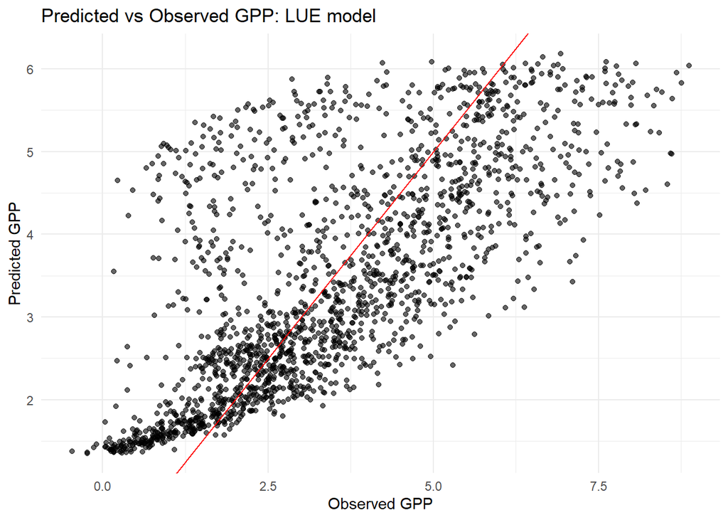

```r
p_model_obs_vs_pred |>
  ggplot(aes(x = gpp, y = gpp_pred)) +
  geom_point(alpha = 0.6) +
  geom_abline(slope = 1, intercept = 0, color = "red") +
  labs(
    x = "Observed GPP",
    y = "Predicted GPP",
    title = "Predicted vs Observed GPP: LUE model"
  ) +
  theme_minimal()
```

### Milestone 5: Fit a multiple linear regression model

We extend the linear model to include multiple predictors (CO2, fAPAR, PPFD, temperature, and VPD) to improve the prediction of GPP.

```
## # A tibble: 6 × 5
##   term           estimate   std.error statistic   p.value
##   <chr>             <dbl>       <dbl>     <dbl>     <dbl>
## 1 (Intercept)     7.60      3.03          2.51  1.21e-  2
## 2 co2            -0.0188    0.00762      -2.47  1.35e-  2
## 3 fapar           0.549     0.671         0.818 4.14e-  1
## 4 ppfd        11467.      234.           49.0   0
## 5 temp            0.0691    0.00652      10.6   1.81e- 25
## 6 vpd            -0.00263   0.0000845   -31.2   7.38e-171
```

[figure not shown]

## Bonus milestone: Fit a non-linear model for GPP~PPFD

We fit a non-linear model to capture the diminishing returns of GPP with increasing PPFD. This is achieved by including a quadratic term for PPFD.

```
## # A tibble: 2 × 5
##   term        estimate std.error statistic  p.value
##   <chr>          <dbl>     <dbl>     <dbl>    <dbl>
## 1 ppfd          15538.      299.      52.0 0
## 2 I(ppfd^2) -11729587.   533508.     -22.0 3.90e-95
```

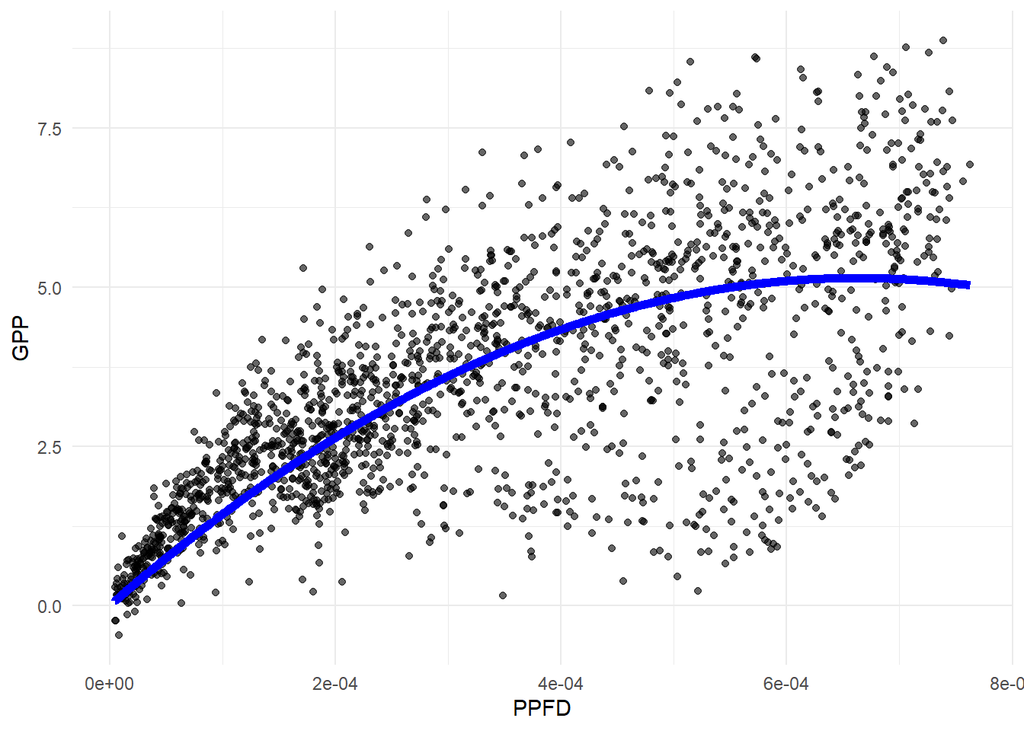